# Exemplos - Revisão Prob - Aula 03

Aishameriane Schmidt

01 de março de 2018

# Introdução

Este código tem alguns exemplos para as distribuições de probabilidade contínuas, para vermos o efeito que mudanças nos parâmetros têm na forma da densidade.

Sugiro visitar este site http://www.artofstat.com/webapps.html nas horas vagas, porque ele tem várias coisas legais de estatística e probabilidade que ajudam a reforçar os conceitos.

# Carregando os pacotes

O R funciona com “pacotes”. Algumas funções básicas são carregadas a cada inicialização, porém a maioria das coisas mais complexas está em pacotes, que são conjuntos de funções desenvolvidos por outros usuários e disponibilizados na internet. Cada vez que abrimos o R, precisamos fazer o carregamento destes pacotes.

```r
chooseCRANmirror(graphics = FALSE, ind = 10)
if (!require("pacman")) install.packages("pacman")
pacman::p_load(ggplot2, reshape2, latex2exp)
```

# Distribuição Exponencial

A distribuição exponencial no R é aquela que tem densidade dada por:

$$f_x(x) = \beta e^{-\beta \cdot x}$$

De maneira que sua média é dada por $1/\beta$.

Vamos fazer o gráfico de diferentes densidades, considerando $\beta = \{0.25, 0.5, 1, 2\}$.

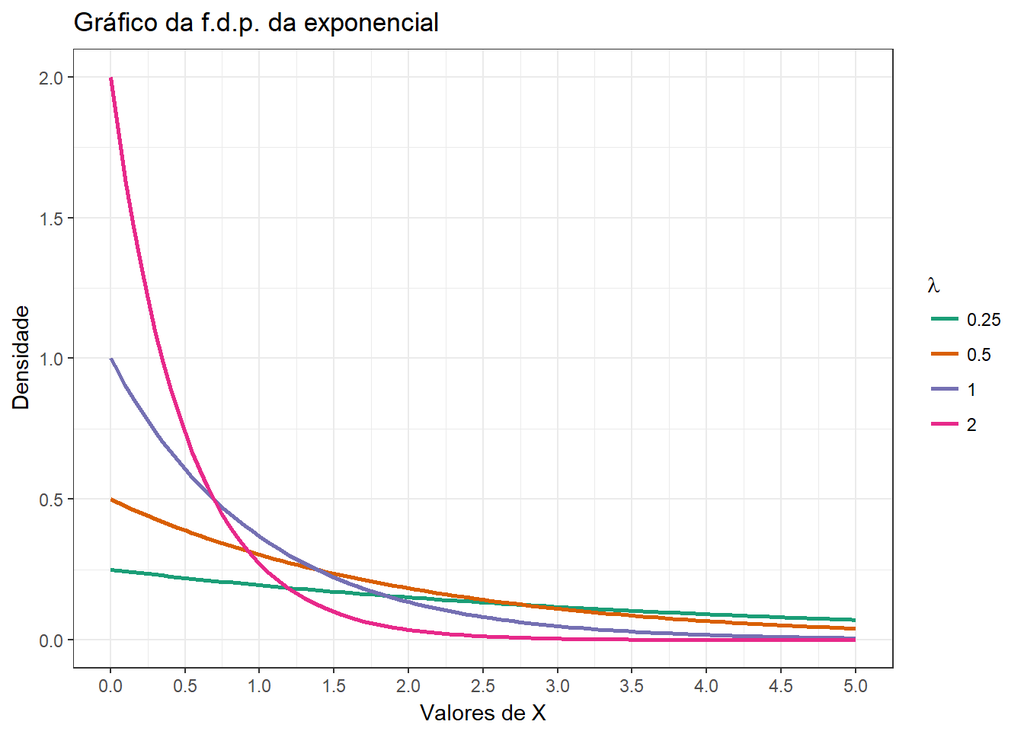

```r
p <- ggplot(data.frame(x = seq(0, 5, 0.05)), aes(x=x)) +
     stat_function(fun = dexp, args = .25,
                   aes(colour =  "0.25"), size = 1) +
     stat_function(fun = dexp, args = .5,
                   aes(colour =  "0.5"), size = 1) +
     stat_function(fun = dexp, args = 1,
                   aes(colour =  "1"), size = 1) +
     stat_function(fun = dexp, args = 2,
                   aes(colour =  "2"), size = 1) +

     scale_x_continuous(name = "Valores de X",
                        breaks = seq(0, 5, 0.5),
                        limits = c(0,5)) +
     scale_y_continuous(name = "Densidade") +

     ggtitle("Gráfico da f.d.p. da exponencial") +
        scale_colour_brewer(palette="Dark2") +
        labs(colour = TeX("$\\lambda$"))

p <- p + theme_bw()
p
```

# Distribuição Gama

Dizemos que uma variável aleatória $X$ tem distribuição Gama com parâmetros$(k,\lambda)$ e denotamos por $X \sim \text{Gama}(k,\lambda)$ se a densidade de $X$ é
$$\begin{align*}
f_{X}(x) =
\begin{cases}
\frac{1}{\Gamma(k)\lambda^{k}} x^{k-1}e^{-\frac{x}{\lambda}} & \mbox{, if $x > 0$} \\
0 & \mbox{, caso contrário}
\end{cases}
\end{align*}$$

Vou usar o pacote gráfico nativo do R para ficar diferente do exemplo anterior.

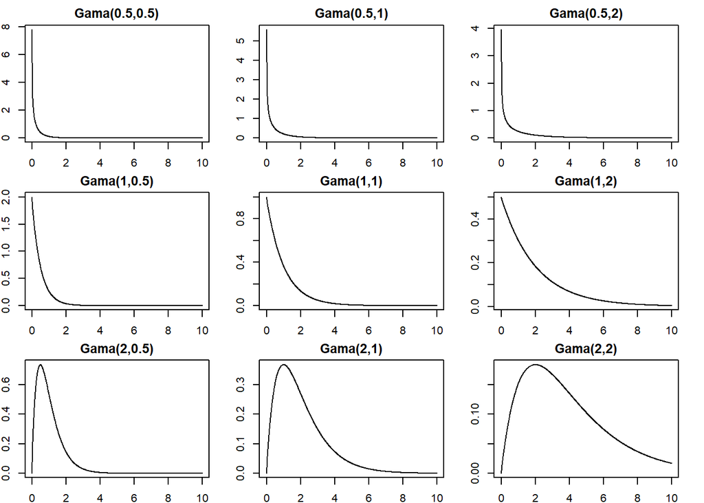

```r
# Gera os valores de x
x <- seq(0, 10, 0.01)

# Gera os vetores com os parâmetros
k <- c(0.5, 1, 2)
lambda <- c(0.5, 1, 2)

# Gera os gráficos
# Configura o grid para múltiplos gráficos
par(mfrow = c(length(k), length(lambda)), mai = c(0.25, 0.25, 0.25, 0.25))

# Não recomendo usar for dentro de for para coisas em geral
for (i in 1:length(k)){
  for (j in 1:length(lambda)){
    plot(x, dgamma(x, shape = k[i], scale = lambda[j]),  type = 'l', ylab = "Densidade", xlab = "", main = paste0("Gama(",k[i],",",lambda[j],")"))
  }
}
```

# Densidade Beta

Dizemos que $X$ tem distribuição Beta com parâmetros $(\alpha,\beta)$ e denotamos por $X \sim \text{Beta}(\alpha,\beta)$ se a densidade de $X$ é
$$\begin{align*}
f_{X}(x) =
\begin{cases}
\frac{\Gamma(\alpha+\beta)}{\Gamma(\alpha)\Gamma(\beta)} \cdot x^{\alpha-1}(1-x)^{\beta-1} & \mbox{, if $0 < x < 1$} \\
0 & \mbox{, caso contrário}
\end{cases}
\end{align*}$$

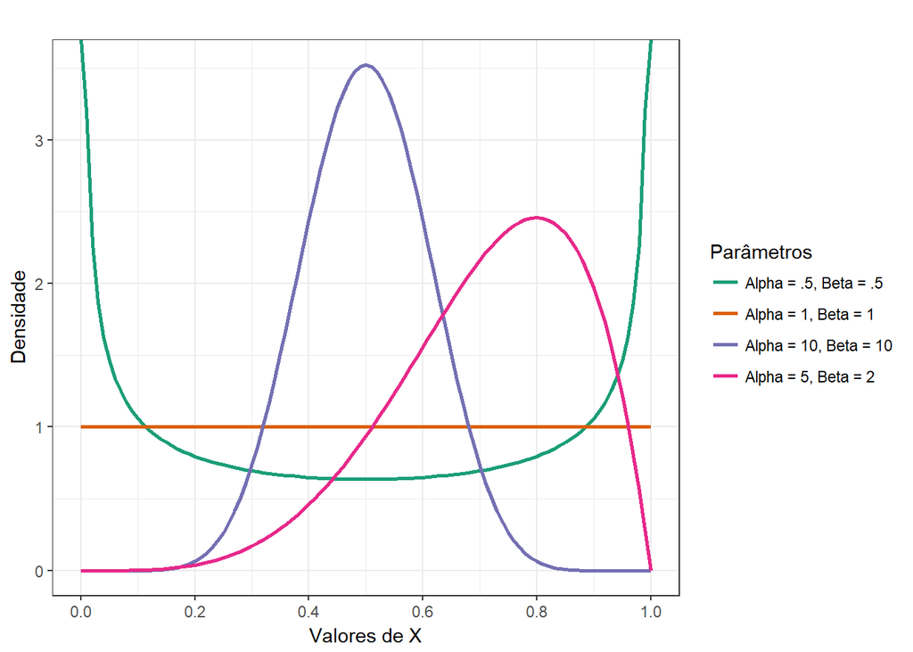

```r
p <- ggplot(data.frame(x = c(0,1)), aes(x=x)) +
     stat_function(fun = dbeta, args = list(.5, .5),
                   aes(colour = "Alpha = .5, Beta = .5"), size = 1) +
     stat_function(fun = dbeta, args = list(1, 1),
                   aes(colour = "Alpha = 1, Beta = 1"), size = 1) +
     stat_function(fun = dbeta, args = list(10, 10),
                   aes(colour = "Alpha = 10, Beta = 10"), size = 1) +
     stat_function(fun = dbeta, args = list(5, 2),
                   aes(colour = "Alpha = 5, Beta = 2"), size = 1) +

     scale_x_continuous(name = "Valores de X",
                        breaks = seq(0, 1, 0.2),
                        limits = c(0,1)) +
     scale_y_continuous(name = "Densidade") +

     ggtitle("") +
        scale_colour_brewer(palette="Dark2") +
        labs(colour = "Parâmetros")

p <- p + theme_bw()
p
```

# Distribuição Normal

```r
#####################################################
#   Exemplo 2: Mudanças nos parâmetros da Normal    #
#####################################################

# O objetivo do exercício é mostrar o que acontece quando variamos os parâmetros da distribuição Normal

# Cria um vetor de valores, de -10 a 10 e tamanho 100
valores <- seq(-10, 10, length=100)

# Cria um vetor para armazenar as médias, desvios padrão e valores da f(x)
medias<-rep(0,4)
desvios<-rep(0,4)
densidade<-matrix(rep(0,400),ncol=4)

# Pede ao usuário os valores de média e desvio padrão para as 4 normais que serão comparadas com a normal padrão
ler_medias <- function()
{
  for (i in 1:4) {
    cat(prompt="\n","Insira a o valor da média ", i, ": ")
    medias[i] <- readline(prompt=" ")
    cat(prompt="\n","Insira a o valor do desvio padrão ", i, ": ")
    desvios[i] <- readline(prompt=" ")
  }
  return(c(as.double(medias),as.double(desvios)))
  cat("Os valores inseridos são:")
  for (i in 1:4){
    cat("\n","Média ", i, " = ", medias[i])
    cat("\n","Desvio Padrão ", i, " = ", desvios[i])
  }
}

# Dados<-ler_medias()
Dados <- c(0, 0, -2, 2, 1, 3, 1, 0.5)
medias<-Dados[1:4]
desvios<-Dados[5:8]

# Calcula o valor da f(x) para cada valor do vetor de valores
# Primeiro calcula o valor da normal padrao
padrao <- dnorm(valores)

# Calcula os valores das demais densidades armazenando em cada uma das colunas da matriz, usando as medias e desvios informados
for (i in 1:4) {
      densidade[,i]<-dnorm(valores,mean=medias[i],sd=desvios[i])
}

# Mostra os primeiros valores da matriz de densidades
head(densidade)
```

```
##              [,1]         [,2]         [,3]          [,4]
## [1,] 7.694599e-23 0.0005140930 5.052271e-15 6.685429e-126
## [2,] 5.684422e-22 0.0006420099 2.491807e-14 1.002353e-121
## [3,] 4.031458e-21 0.0007981277 1.179826e-13 1.276480e-117
## [4,] 2.744818e-20 0.0009877195 5.362862e-13 1.380733e-113
## [5,] 1.794074e-19 0.0012168177 2.340189e-12 1.268549e-109
## [6,] 1.125752e-18 0.0014922720 9.803492e-12 9.899348e-106
```

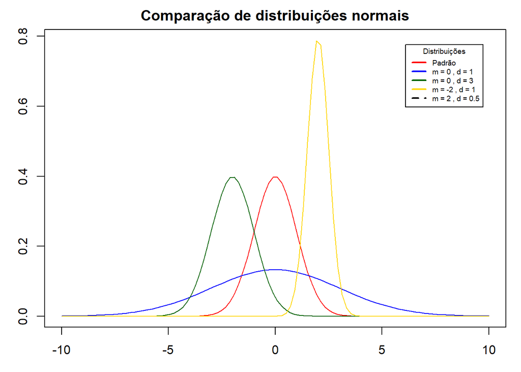

```r
# Faz os gráficos, 1 a 1
# Cria um vetor para as cores
cores <- c("red", "blue", "darkgreen", "gold", "black")
# Ajusta as margens
par(mar=c(3,3,2,1))
# Plota a distribuição normal padrão
plot(valores,padrao,type="l",main="Comparação de distribuições normais",xlab="Valores de x",ylab="Densidade", ylim=c(0,max(densidade)))
# Plota a legenda
labels_aux<-rep(0,4)
for (i in 1:4) {
  labels_aux[i]<-paste("m =",medias[i],", d =",desvios[i])
}
labels <- c("Padrão", labels_aux[1], labels_aux[2], labels_aux[3], labels_aux[4])
legend("topright", inset=.05, title="Distribuições", legend=labels, lwd=2, lty=c(1, 1, 1, 1, 2), col=cores,cex=0.6)

# Plota os outros gráficos, 1 a 1
lines(valores, densidade[,1],col=cores[1])
lines(valores, densidade[,2],col=cores[2])
lines(valores, densidade[,3],col=cores[3])
lines(valores, densidade[,4],col=cores[4])
```

# Distribuição t

Primeiro, vamos ver numa animação o que significa dizer que “a t tem caudas mais pesadas que a normal”, neste link: https://istats.shinyapps.io/tdist/

```r
#############################################################
#   Exemplo 3: Mudanças nos graus de liberdade da t         #
#############################################################

# O objetivo do exercício é mostrar o que acontece quando variamos o parâmetro da distribuição t de student

# Cria um vetor de valores, de -10 a 10 e tamanho 100
valores <- seq(-4, 4, length=100)

# Cria um vetor para armazenar os graus de liberdade e valores da f(x)
gl<-rep(0,4)
densidade<-matrix(rep(0,400),ncol=4)

# Pede ao usuário os valores de média e desvio padrão para as 4 distribuições t que serão comparadas com a t de 1gl e a normal padrão
ler_gl <- function()
{
  for (i in 1:4) {
    cat(prompt="\n","Insira a o valor dos g.l. da distribuição ", i, ": ")
    gl[i] <- readline(prompt=" ")
  }
  return(c(as.double(gl)))
  cat("Os valores inseridos são:")
  for (i in 1:4){
    cat("\n","G.L. ", i, " = ", medias[i])
  }
}

#Dados<-ler_gl()
Dados <- c(1,5,20,30)

# Calcula o valor da f(x) para cada valor do vetor de valores
# Primeiro calcula o valor da normal padrao
t_1gl <- dt(valores, df=1)

# Calcula os valores das demais densidades armazenando em cada uma das colunas da matriz, usando as medias e desvios informados
for (i in 1:4) {
  densidade[,i]<-dt(valores,df=Dados[i])
}


# Mostra os primeiros valores da matriz de densidades
head(densidade)
```

```
##            [,1]        [,2]         [,3]         [,4]
## [1,] 0.01872411 0.005123727 0.0008224743 0.0005247164
## [2,] 0.01945652 0.005622201 0.0009929137 0.0006519723
## [3,] 0.02023174 0.006175213 0.0011980625 0.0008089245
## [4,] 0.02105311 0.006789265 0.0014447321 0.0010021115
## [5,] 0.02192425 0.007471675 0.0017409815 0.0012393863
## [6,] 0.02284916 0.008230681 0.0020963185 0.0015301436
```

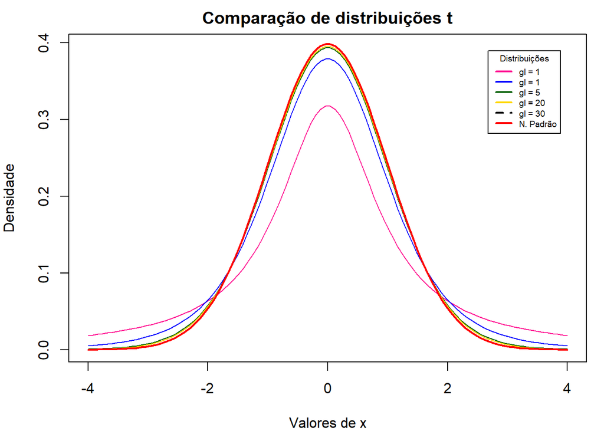

```r
# Faz os gráficos, 1 a 1
# Cria um vetor para as cores
cores <- c("deeppink", "blue", "darkgreen", "gold", "black", "red")
# Ajusta as margens
par(mar=c(4,4,2,1))
# Plota a distribuição normal padrão
plot(valores,t_1gl,type="l",col=cores[5],main="Comparação de distribuições t",xlab="Valores de x",ylab="Densidade", ylim=c(0,max(densidade)))
# Plota a legenda
labels_aux<-rep(0,4)
for (i in 1:4) {
  labels_aux[i]<-paste("gl =",Dados[i])
}
labels <- c("gl = 1", labels_aux[1], labels_aux[2], labels_aux[3], labels_aux[4], "N. Padrão")
legend("topright", inset=.05, title="Distribuições", legend=labels, lwd=2, lty=c(1, 1, 1, 1, 2), col=cores,cex=0.6)

# Plota os outros gráficos, 1 a 1
lines(valores, densidade[,1],col=cores[1])
lines(valores, densidade[,2],col=cores[2])
lines(valores, densidade[,3],col=cores[3])
lines(valores, densidade[,4],col=cores[4])
lines(valores, dnorm(valores),col=cores[6], lwd=2)
```

```r
# Plota o gráfico da diferença entre cada distribuição e a normal padrão
dif<-dnorm(valores)-cbind(t_1gl,densidade)
head(dif)
```

```
##            t_1gl
## [1,] -0.01859028 -0.01859028 -0.004989897 -0.0006886441 -0.0003908862
## [2,] -0.01927222 -0.01927222 -0.005437906 -0.0008086183 -0.0004676770
## [3,] -0.01997961 -0.01997961 -0.005923075 -0.0009459244 -0.0005567865
## [4,] -0.02071040 -0.02071040 -0.006446555 -0.0011020222 -0.0006594016
## [5,] -0.02146147 -0.02146147 -0.007008890 -0.0012781969 -0.0007766017
## [6,] -0.02222829 -0.02222829 -0.007609818 -0.0014754562 -0.0009092813
```

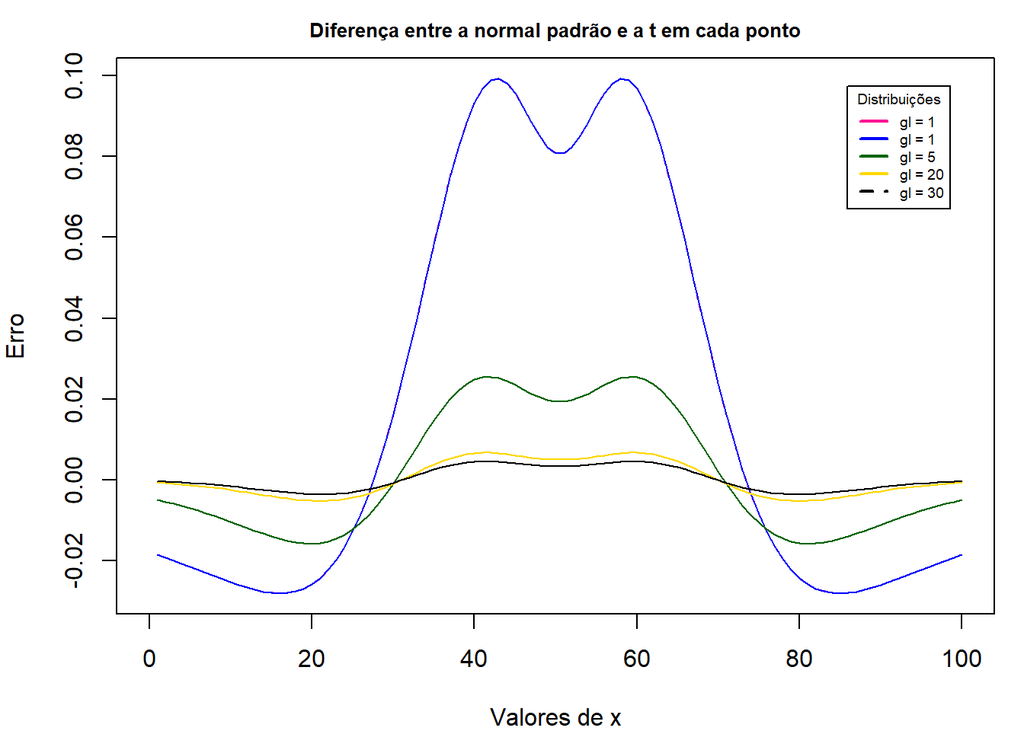

```r
plot(dif[,1],xlim=c(0,100), xlab="Valores de x",ylab="Erro", type='l', lty = 2, col=cores[1], main="Diferença entre a normal padrão e a t em cada ponto",cex.main=0.8)

lines(dif[,2], type='l',col=cores[2])
lines(dif[,3], type='l',col=cores[3])
lines(dif[,4], type='l',col=cores[4])
lines(dif[,5], type='l',col=cores[5])

labels_aux<-rep(0,4)
for (i in 1:4) {
  labels_aux[i]<-paste("gl =",Dados[i])
}
labels <- c("gl = 1", labels_aux[1], labels_aux[2], labels_aux[3], labels_aux[4])
legend("topright", inset=.05, title="Distribuições", legend=labels, lwd=2, lty=c(1, 1, 1, 1, 2), col=cores,cex=0.6)
```